# MATH70076: Data Science - Formative Assessment

MSc in Statistics 2026/27, Imperial College London

Author

06025319

**Deadline: Monday 12 October 2026 at 13:00.**

*For this formative assessment you should submit two files via the Imperial College VLE on Canvas by the deadline stated above. Your files should be named as follows:*

- `YOURCID-MATH70076-formative-assessment.pdf`: your rendered report,
- `YOURCID-MATH70076-formative-assessment.zip`: a zip file containing the relevant source code to generate your report.

*All submitted materials should be clearly presented and be understandable as stand-alone documents.*

*Please note that large files can take quite some time to upload. Ensure that you upload each document to the correct part of the learning space in a timely manner.*

*This mock coursework is a formative assessment and so will not contribute to your overall grade for the module. It is designed for you to practice the skills you have learned in the first workshop and to get feedback on your reflective writing style. This activity is expected to take approximately 6 hours of individual effort. Assessment criteria are given in the “set yourself up for success” boxes. Satisfying 18 or more out of these 23 criteria corresponds to a notional “pass” grade.*

*In submitting this mock assessment you certify that it is entirely your own work, apart from where otherwise acknowledged, and includes no plagiarism. Note that software tools are used as part of plagiarism detection.*

## Background

### Generalised Pareto Distribution

The Generalized Pareto Distribution (GPD) is a flexible family of continuous probability distributions that arises naturally in extreme value theory, particularly for modelling the distribution of excesses over a threshold. It is parametrised by a shape parameter $\xi \in \mathbb{R}$, a scale parameter $\sigma > 0$, and a location parameter $u \in \mathbb{R}$. Its cumulative distribution function (CDF) is given by

$$F(x;\,\sigma,\xi, u) =
\begin{cases}
1 - \left(1 + \dfrac{\xi (x-u)}{\sigma}\right)_+^{-1/\xi}, & \xi \neq 0, \, x \geq u; \; \\[1.2em]
1 - \exp\!\left(-\dfrac{x-u}{\sigma}\right), & \xi = 0, \, x \geq u;
\end{cases}
\tag{1}$$

where $x_+ = \max(x,0)$ and its probability density function (PDF) is

$$f(x;\sigma,\xi,u) =
\begin{cases}
\dfrac{1}{\sigma}\left(1 + \dfrac{\xi (x-u)}{\sigma}\right)_+^{-1/\xi - 1}, & \xi \neq 0, \\[1.2em]
\dfrac{1}{\sigma}\exp\!\left(-\dfrac{x-u}{\sigma}\right), & \xi = 0,
\end{cases}
\tag{2}$$

defined on the same support as the CDF. The GPD encompasses a variety of tail behaviours:

- when $\xi > 0$ the GPD has heavy, slowly decaying tails,
- in limiting case when $\xi \rightarrow 0$ the GPD reduces to an exponential distribution;
- when $\xi < 0$ the GPD has light, quickly decaying tails with a finite upper endpoint of $x^+ = u - \sigma / \xi$.

### Probability Integral Transform

The probability integral transform states that if a random variable $X$ has a continuous cumulative distribution function $F_X(x)$, then the transformed variable $A = F_X(X)$ follows a uniform distribution on $[0,1]$. Conversely, if $F$ is an invertible function then $Y = F^{-1}_X(A)$ has the same distribution as $X$.

## Questions

### Question 1

Derive an expression for the inverse cumulative distribution function (also known as the quantile function) $F^{-1}_X: [0,1] \rightarrow [u, x^+]$ of $X \sim \text{GPD}(u, \sigma, \xi)$. Your answer should refer to at least one equation given in the background material.

**TipSet yourself up for success**

Does your answer contain:

- a few sentences of text describing your approach to the problem;
- a reference to at least one equation from the background section;
- a correctly formatted LaTeX equation;
- a valid approach to the problem and correct expression.

### Solution_Q1

The inverse $F^{-1}$ of the CDF of the pareto distribution is the function that maps $(0,1]\rightarrow[u,x^+]$ such that $F(F^{-1})(x) = x$. This function is traditionally found by switching the x and y variables in the function we’re looking to invert, and then by isolating the variables and solving for y. Often in math, it’s helpful to break down this into two cases, one where $\xi=0$, so essentially the exponential distribution.

Equation 1 tells us the CDF for $\xi=0$, so let us start by switching the variables.

$$x = 1 - \exp\!\left(-\dfrac{y-u}{\sigma}\right)$$
Next, we follow through with isolating the y variable in the following steps.

1. Isolate the exponential expression.

$$\exp\!\left(-\dfrac{y-u}{\sigma}\right) = 1-x$$

2. Take the natural log of both sides and simplify.

$$\dfrac{y-u}{\sigma} = -\ln(1-x)$$

3. Solve for y to get
   $$F^{-1} = u -\sigma\ln(1-x)$$

Now, let’s do the same with the case where $\xi\neq0$, again starting from Equation 1 and switching the variables.

$$x = 1 - \left(1 + \dfrac{\xi (y-u)}{\sigma}\right)^{-1/\xi}$$

4. Isolating the exponent term

$$\left(1 + \dfrac{\xi (y-u)}{\sigma}\right)^{-1/\xi} = 1-x$$

5. Raising both sides to the $-\xi$ and re-arranging

And finally,
$$y = \dfrac{\sigma}{\xi}\left((1-x)^{-\xi}-1\right) + u$$

So,

$$F^{-1}(x) = \begin{cases}
\dfrac{\sigma}{\xi}\left((1-x)^{-\xi}-1\right) + u, & \xi\neq0,\, x\in[0,1) \\[1.2em]
u -\sigma\ln(1-x), & \xi=0, \, x\in[0,1)
\end{cases}$$

### Question 2

*For this question you should display the R code you use to define and document `qgpd()` within the main text of your report.*

1. Write and document your own function `qgpd()` to calculate quantiles of a given generalised Pareto distribution. Your function should have inputs and behaviour similar to the built-in R functions such as `qnorm()` and `qunif()` and check that inputs are in the correct format.
2. Suppose a random variable $X$ follows an generalised Pareto distribution with threshold parameter $u=1.5$, scale parameter $\sigma = 2$ and shape parameter $\xi = -0.4$. Use your function to find quantiles $x_p$ for $p = 0.5, 0.75, 0.99$ (i.e. for each $p$ find the value for which $\Pr(X < x_p) = p$).

**TipSet yourself up for success**

Does your answer:

- contain a valid R function definition;
- document the expected inputs, outputs and behaviours of that function;
- check the validity of inputs;
- handle any edge-cases in an appropriate way;
- return the correct quantile values?

### Solution_Q2

#### Part A

The standard R quantile functions take in the distribution parameters, a probability $p$, and then compute X such that $P(X\leq X) = p$

```r
#' Quantile function for the Generalized Pareto Distribution
#'
#' @param p - probability value
#' @param mu - threshold of the pareto distribution
#' @param sigma - scale parameter, must be >0
#' @param xi - shape parameter; affects the shape of the curve. At xi=0 the function evaluates the quantile of the exponential function.
#' @param lower.tail - Default set to TRUE, calculating P(X<=x). When FALSE evaluates P(x>X). So if p = .95, setting this to FALSE calculates P(x>X) = 0.95, so the 5th percentile
#' @param log.p - Default set to FALSE. If inputted p is actually a log probabilty, then set to true and the function will evaluate the quantile for p<- exp(p)
#'
#' @returns X s.t. P(X<=X) = p
#'
#' @examples
#' ## Using "log = TRUE" evaluates P(X<=x) = exp(-2) for the distribution)
#'   qgpd(-2,1,1,0,log.p = TRUE)
#'
#'#' ## Using "lower.tail=FALSE" evaluates P(X>x) = 0.4, so the 60th quantile.
#'   qgpd(0.4,1,1,0,lower.tail=FALSE)
#'


qgpd<-function(p, mu,sigma,xi,lower.tail=TRUE,log.p=FALSE) {
  stopifnot(sigma>0)
  stopifnot(typeof(lower.tail)=="logical")
  stopifnot(typeof(log.p)=="logical")

  if (log.p== TRUE) {
    p<-exp(p)
  }
 if (lower.tail==FALSE) {
    p = 1-p
 }
  stopifnot(p >= 0)
  stopifnot(p <= 1)

  if (xi == 0) {
    return(mu-sigma*log((1-p),exp(1))) }
  else
    return((sigma/xi)*((1-p)**(-1*xi) - 1) + mu)
}
```

#### Part B

```r
qgpd(0.5,mu = 1.5,sigma =2, xi=-0.4)
qgpd(0.75,mu = 1.5,sigma =2, xi=-0.4)
qgpd(0.99,mu = 1.5,sigma =2, xi=-0.4)
```

```
[1] 2.710709
[1] 3.628254
[1] 5.707553
```

### Question 3

*For this question, all R code should be displayed only within the appendix, not in the main report.*

The file `gpd_samples.csv` contains six sets of random variates generated from different generalised Pareto distributions. The details of the generalised Pareto distributions used are summarised in `gpd_parameters.csv`. Unfortunately some of the parameter sets were recorded incorrectly.

Within a single figure, construct a series of quantile-quantile plots to identify which datasets are inconsistent with their stated distributions. You should both justify your conclusions and describe your level of confidence in your findings.

**TipSet yourself up for success**

Does your solution contain:

- at least one quantile-quantile plot;
- six qq-plots in a single figure;
- use of loops, vectorisation, or function definitions to avoid repetitive code.
- figures with clear text, useful captions and appropriate visual mapping of data;
- a few paragraphs describing and justifying your findings and referencing the figure;

### Solution_Q3

The provided data has variates and parameters across six different sets. We’ve learned that some of our parameter data might be wrong, so a tool we have to see which sample variates seem appropriate given the parameters, we can use a Q-Q plot to compare (1) theoretical quantile values given the potentially incorrect parameters to (2) the quantiles in the observed data. The best evidence that the parameters are correct for any given set would be if the plot of (theoretical, observed) across the quantiles follows the line y=x.

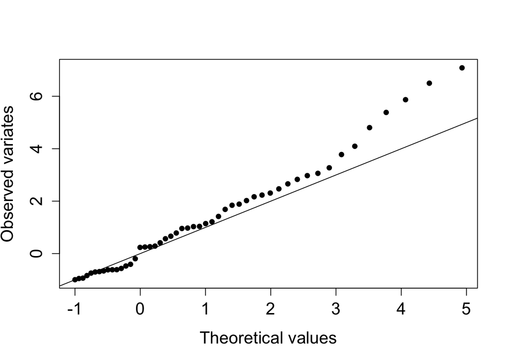

(a) Set A: mu = -1, sigma = 3, xi = -0.4

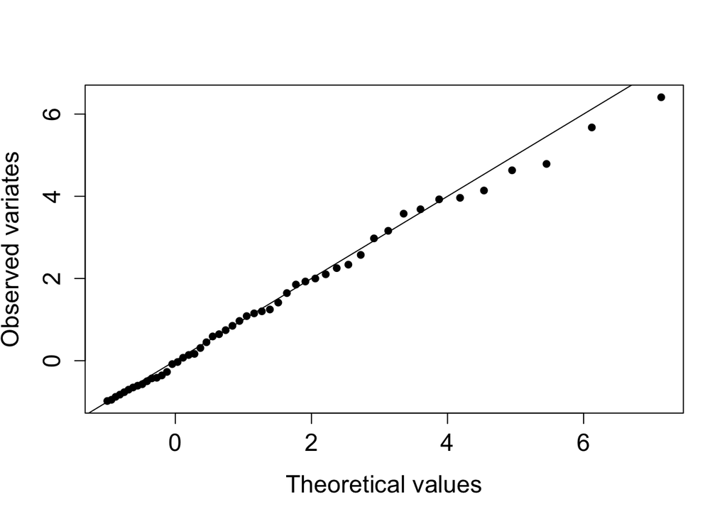

(b) Set B: mu = -1, sigma = 3, xi = -0.2

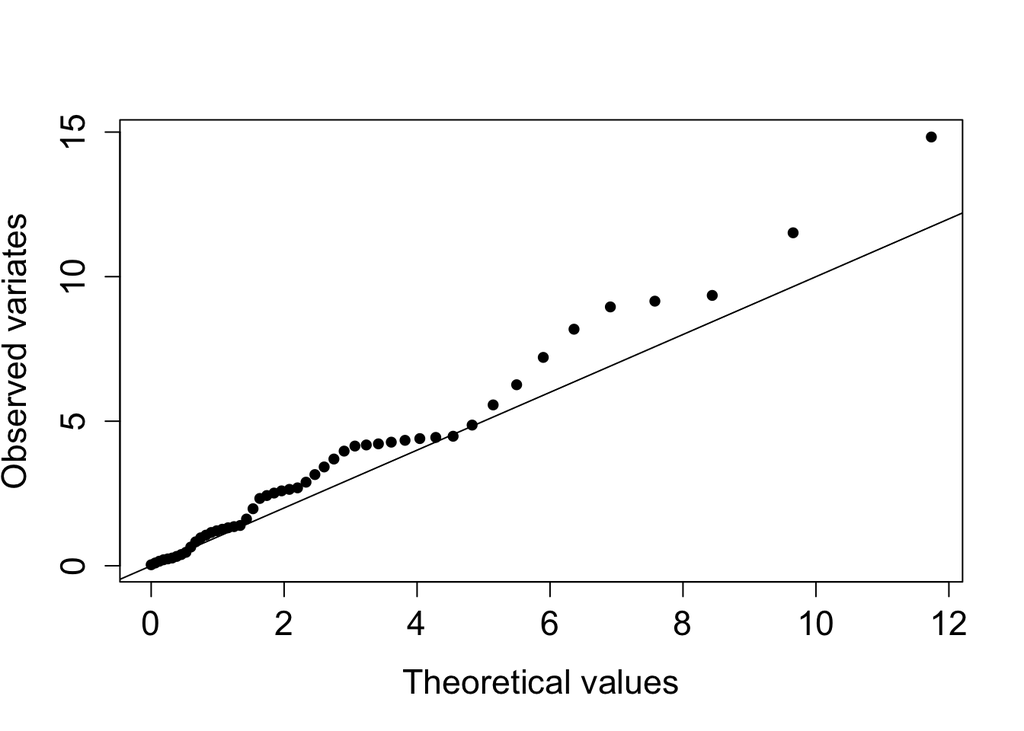

(c) Set C: mu = 0, sigma = 3, xi = 0

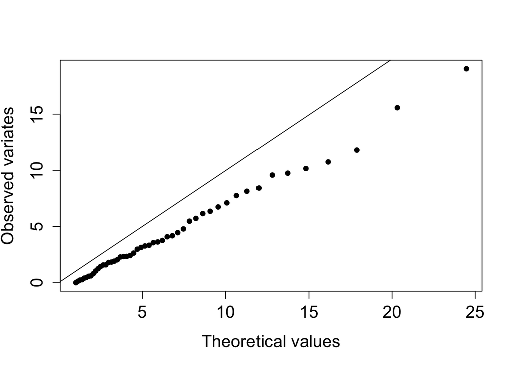

(d) Set D: mu = 1, sigma = 6, xi = 0

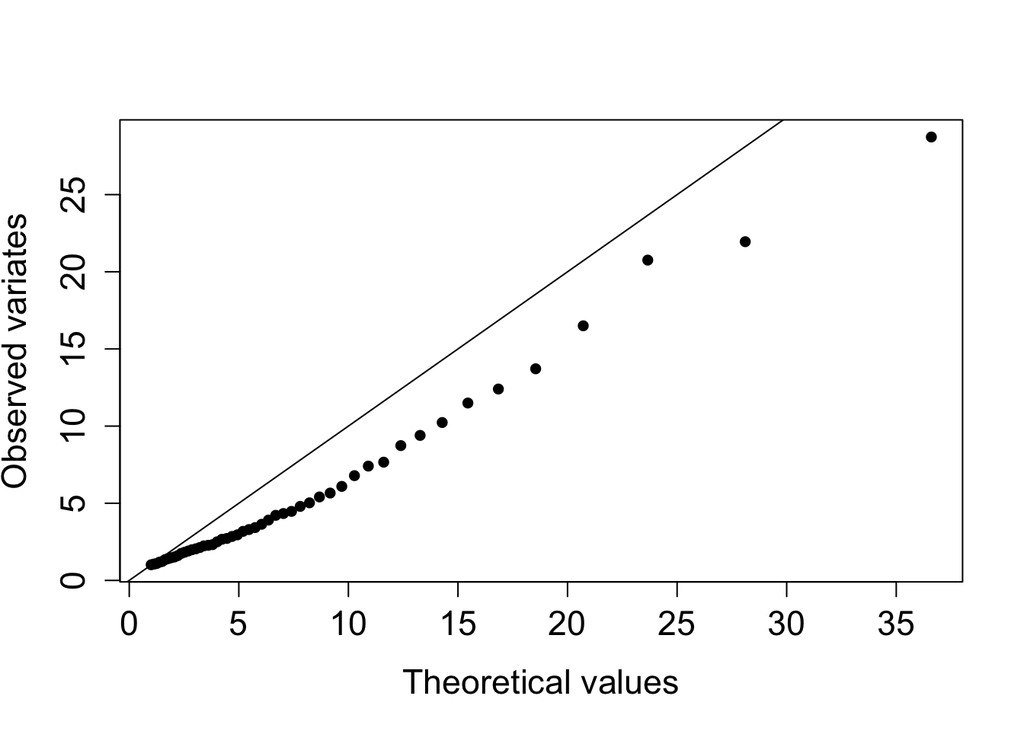

(e) Set E: mu = 1, sigma = 6, xi = 0.2

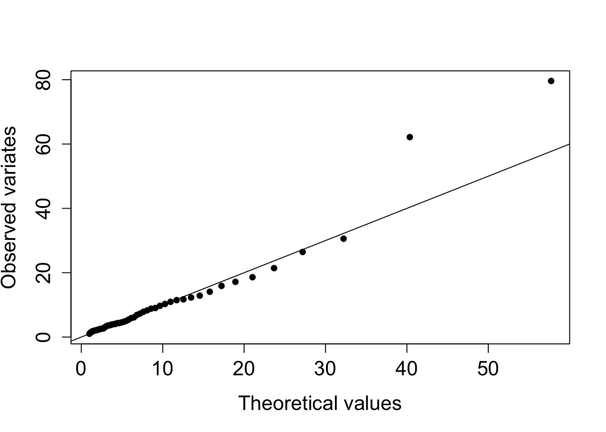

(f) Set F: mu = 1, sigma = 6, xi = 0.4

Figure 1: Q-Q plots of GPD samples across 6 sets against theoretical values

### Question 4

*For this question, all R code should be displayed only within the appendix, not in the main report.*

A hydrologist is interested in understanding the river flow at a location that is historically prone to flooding. There is a river flow gauge nearby which measures river flow in units of cubic meters per second ($\text{m}^3/\text{s}$ or cumecs). Based on her knowledge of other rivers, the hydrologist proposes that for this river gauge:

- the distribution of river flow values is constant over time
- for river flows exceeding 75 cumecs, it is appropriate to model these data as independent and identically distributed GPD($\sigma =29.7$, $\xi=0.62$, $u = 0$).

Use `riverflow_2015-2024.csv` to conduct an exploratory investigation of whether these proposals are valid for the dataset provided. Summarise your findings in 250-350 words, supporting these with a collection of 4 visualisations/figures.

**TipSet yourself up for success**

Does your answer contain:

- 400-500 words of text clearly describing your choice of visualisations, their interpretation and your conclusions about the validity of each assumption,
- A series of 4 visualizations / figures,
- A varied and appropriate choice of figures to investigate each of the hydrologist’s proposals,
- Figures with clear text, useful captions and appropriate visual mapping of data;
- At least one reference to each visualisation within the main text.

### Solution_Q4

The hydrologist has made 2 proposals, namely (1) that the distribution of flows is constant over time, and (2) that flows above 75 are distributed according to the GPD with the provided parameters. I want to use two plots to preliminarily evaluate both of these proposals.

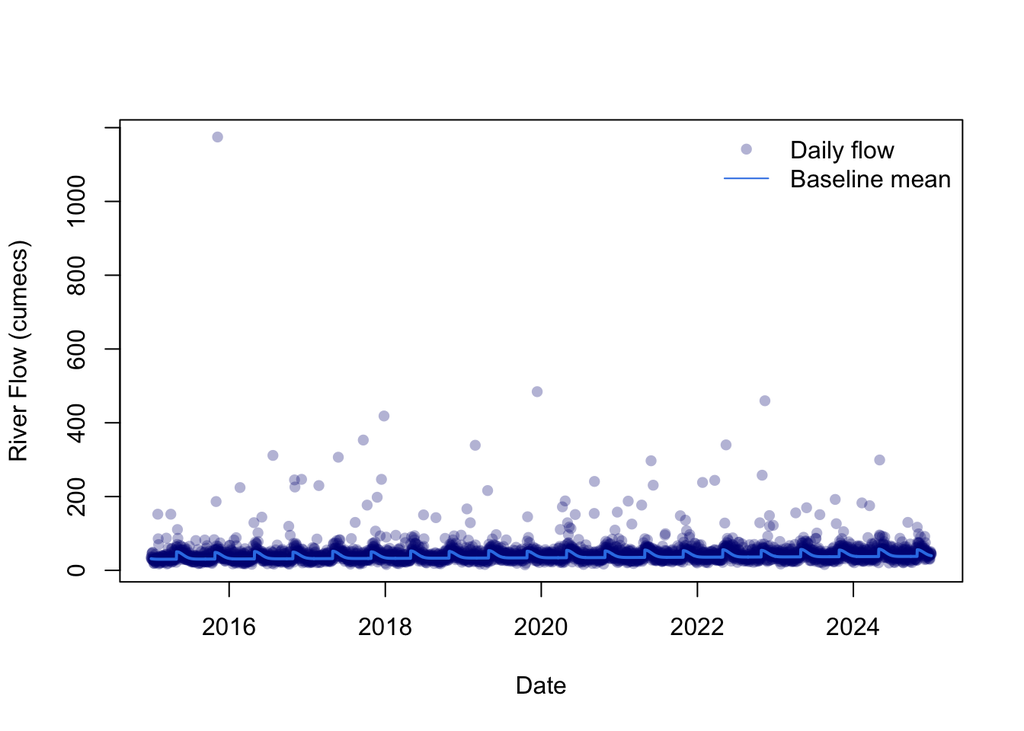

Figure 2: Daily baseline mean and actual flow readings across all daily observations

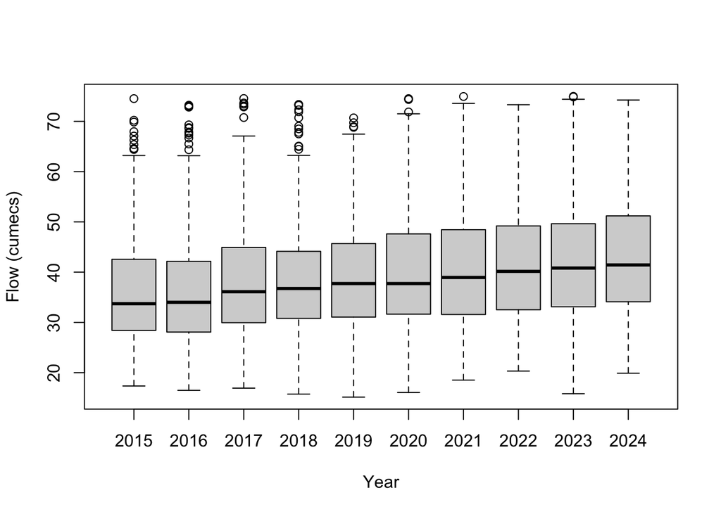

Figure 3: Yearly distribution of flows for non-extreme (<=75 c) days

Switching gears to the second part of the proposal, my first instinct is to make a histogram of the daily flow observations above seventy-five cumecs in order to see if the shape of the curve follows the shape of the GPD. Figure 4 shows that the underlying bars do seem to follow the shape of a pareto distribution from first glance based on our analysis in previous exercises. But to be sure, I overlaid a set of points following the theoretical density function for a GPD function with the provided parameters. Figure 4 shows that the observed excess flows closely follow the theoretical density function.

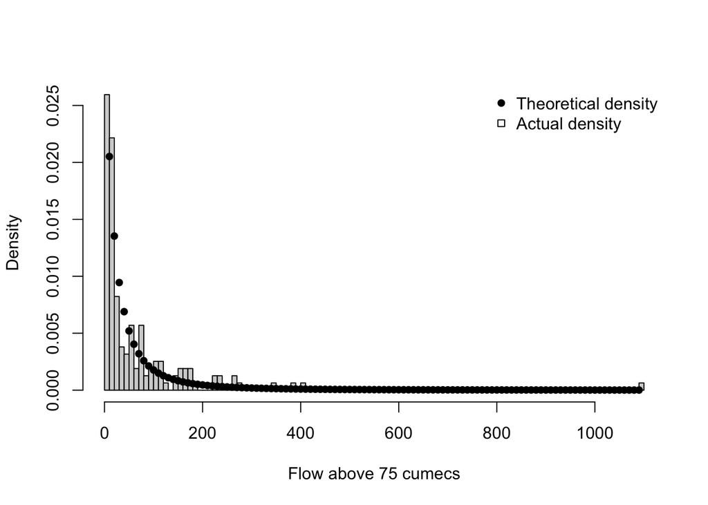

Figure 4: Density of flow events by magnitude of excess, overlaid with theoretical values

So, a preliminary look at the data suggests that part 1 of the proposal may not be true, and part 2 of the proposal seems to hold. However, we’d need to do more analysis to be sure.

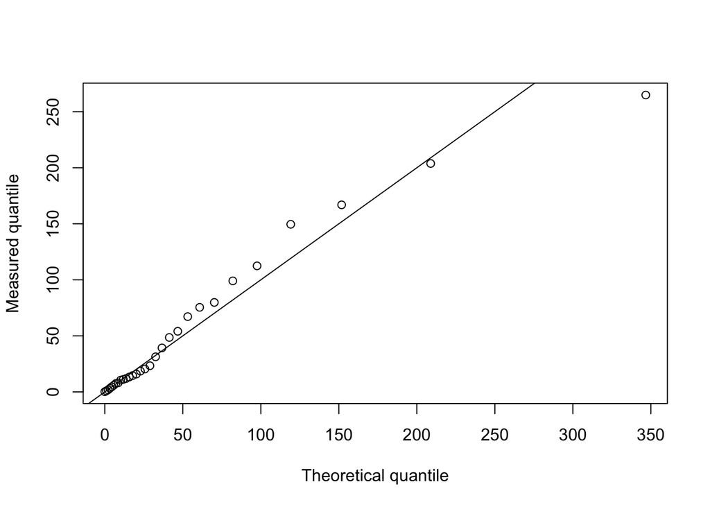

Figure 5: Q-Q plot for river flow above 75 cumecs

**TipSet yourself up for success**

- Does your document render without any formatting issues?

## Question 5 Reflective Summary

Describe, evidence and reflect on the process of constructing the visualisations in your answer to Question 4.

Your response should be 300-400 words and might, for example, comment on:

- why you chose these forms of visualisation and what alternatives you considered;
- a challenge you faced or something that you learned while making the visualisations;
- how you might approach this task differently with more time or for a different intended audience.

### Solution_Q5

I approached this question as a preliminary exercise in sense checking the hydrologist’s proposals. This might be for a team member or manager as a quick answer to “how does the proposal look”, but it’s not a final analysis or recommendation I might offer as the role of an “auditor”.

As such, my visualizations were much more for personal exploration and building my own conviction of what the answers might be about the proposal. If I were to present this in a more formal setting, I’d make some changes:

1. I’d explore some more visualizations, as I could have conducted a much more thorough analysis. For instance, I could have overlaid several more distributions with different parameters on Figure 4, or even used a fitting algorithm to find the parameters which actually best match the observed data. On part 1 of the proposal, I could have conducted and plotted some t-tests to show and quantify how different the flows look across years, improving my more directional “the medians are increasing”.
2. I’d do more rigorous visualization, for example with the treatment and visualization of outliers. Figure 2 is not complete. There are several outliers that drive up the y-axis limits and make it much more difficult to view a majority of the samples. If I were to present this chart, I might choose to exclude outliers, or better yet to choose a different scale (e.g., log(Flows)) to more clearly visualize the trends.
3. I’d further clean up my presentation. I did not know how to represent the histogram boxes in the legend for Figure 4, so I instead opted to use a square to represent the sampled values. I’m not sure if there’s a better way to do this, but a more formal presentation would demand a closer attention to my visual presentation.
4. I’d put in more effort to make my visualizations accessible. None of my visualizations require distinguishing between classes, but Figure 2 uses colors that some readers might find difficult to distinguish, particularly the baseline mean line vs. the flow points. For an external-facing analysis, I would put in much more effort to ensure that people with various abilities were able to engage with my visualizations.

**TipSet yourself up for success**

Does your response:

- describe how you engaged with the visualisation activity;
- give specific evidence of that engagement;
- critically reflection on that engagement?

*End of Assessment.*

# Code Appendix

```r
#' Quantile function for the Generalized Pareto Distribution
#'
#' @param p - probability value
#' @param mu - threshold of the pareto distribution
#' @param sigma - scale parameter, must be >0
#' @param xi - shape parameter; affects the shape of the curve. At xi=0 the function evaluates the quantile of the exponential function.
#' @param lower.tail - Default set to TRUE, calculating P(X<=x). When FALSE evaluates P(x>X). So if p = .95, setting this to FALSE calculates P(x>X) = 0.95, so the 5th percentile
#' @param log.p - Default set to FALSE. If inputted p is actually a log probabilty, then set to true and the function will evaluate the quantile for p<- exp(p)
#'
#' @returns X s.t. P(X<=X) = p
#'
#' @examples
#' ## Using "log = TRUE" evaluates P(X<=x) = exp(-2) for the distribution)
#'   qgpd(-2,1,1,0,log.p = TRUE)
#'
#'#' ## Using "lower.tail=FALSE" evaluates P(X>x) = 0.4, so the 60th quantile.
#'   qgpd(0.4,1,1,0,lower.tail=FALSE)
#'


qgpd<-function(p, mu,sigma,xi,lower.tail=TRUE,log.p=FALSE) {
  stopifnot(sigma>0)
  stopifnot(typeof(lower.tail)=="logical")
  stopifnot(typeof(log.p)=="logical")

  if (log.p== TRUE) {
    p<-exp(p)
  }
 if (lower.tail==FALSE) {
    p = 1-p
 }
  stopifnot(p >= 0)
  stopifnot(p <= 1)

  if (xi == 0) {
    return(mu-sigma*log((1-p),exp(1))) }
  else
    return((sigma/xi)*((1-p)**(-1*xi) - 1) + mu)
}

qgpd(0.5,mu = 1.5,sigma =2, xi=-0.4)
qgpd(0.75,mu = 1.5,sigma =2, xi=-0.4)
qgpd(0.99,mu = 1.5,sigma =2, xi=-0.4)


gpd_samples<-read.csv("gpd_samples.csv")
gpd_params<- read.csv("gpd_parameters.csv")
granularity = 50
sets<-c("a","b","c","d","e","f")

for (i in 1:length(sets)) {
  x = seq(0,1-1/granularity,by = 1/granularity)
  u<- gpd_params[gpd_params$id==sets[i],]$u
  sigma<- gpd_params[gpd_params$id==sets[i],]$sigma
  xi<- gpd_params[gpd_params$id==sets[i],]$xi

  theoretical<-qgpd(x,u,sigma,xi)
  variates<-gpd_samples[gpd_samples$set_id==sets[i],]$value
  quantiles<-quantile(variates,x)

  plot(theoretical,quantiles,xlab = "Theoretical values", ylab = "Observed variates", pch = 16, cex.axis = 1.4, cex.lab = 1.4,abline(a=0,b=1))
  }

river_flow<-read.csv("riverflow_2015_2024.csv")
river_flow$date<- as.Date(river_flow$date)
plot(river_flow$date,river_flow$flow, pch = 16, col = rgb(0,0,.5,.3),xlab = "Date",ylab = "River Flow (cumecs)")
lines(river_flow$date,river_flow$baseline_mean, col = rgb(0.2,0.5,0.9,1),lwd = 2)

legend("topright",legend = c("Daily flow","Baseline mean"),bty = "n",pch = c(16,NA),col = c(rgb(0,0,.5,.3),rgb(0.2,0.5,0.9,1)),lty = c(NA,1))
river_flow<-read.csv("riverflow_2015_2024.csv")
river_flow$date<- as.Date(river_flow$date)
river_flow$year <- as.factor(format(river_flow$date, "%Y"))
standard_flows<- river_flow[river_flow$flow<=75,]
plot(standard_flows$year,standard_flows$flow,xlab = "Year",ylab = "Flow (cumecs)")

gpd_density<- function(x,mu,sigma,xi) {
  return((1/sigma)*(1 + xi*(x-mu)/sigma)**(-1/xi-1))

}

excess_events<-river_flow[river_flow$flow>=75,]
hist(excess_events$flow-75,breaks = 100, freq=FALSE, xlab = "Flow above 75 cumecs", main = "")
x<- seq(0,max(excess_events$flow-75),by=10)
points(x,gpd_density(x,0,29.7,0.62), pch=16)
legend("topright",legend = c("Theoretical density","Actual density"), bty = "n",pch = c(16,22))


granularity = 30
x = seq(0,1-1/granularity,by = 1/granularity)
theoretical<-qgpd(x,0,29.7,0.62)
measured<-quantile(excess_events$flow-75,x)

plot(theoretical,measured, xlab = "Theoretical quantile", ylab = "Measured quantile")
abline(a=0,b=1)
```